# Assignment 1

Injamuri Krutika

Mtech CS

18MCMT20

## Question 1 :

Search the Web for Cumani colour edge detector and write a report on it. Analyse how it may be better than doing Sobel edge detection three times on an RGB image.

## Cumani Edge Detection

The Eigen values of matrix A so happen to coincide with the extremes of S(p;n)  
$A = \begin{pmatrix} K & F\\ F & H \end{pmatrix}$

The squared local contrast of the vector-valued image function C, dependent on location and direction, is defined by S(p;n+). Edge points, i.e., discontinuities of the image function that are characterized by a particularly high contrast, are sought.

The zeros of the derivative, which represent the maxima, are to be determined. In order to find the zeros, the derivatives of this function can also be formed in direction given by

$ \quad \quad D_S(p: n) = K_x.n_1^3 + (K_y +2F_x).n_1n_2 + (H_x+2F_y)n_1n_2 + H_y.n_2^3$.

where the indices x and y denote the corresponding derivatives to x and y

Altogether $D_S(p;n+)$ is a form that is based on the second directional derivatives of the image function. The edgepoints, which were defined as the maximum points of the first derivative of the image function, are represented in $D_S(p;n+)$ by zeros (or zero-crossings in the digital grid). For the detection of these zero-crossings neighboring func-tion values with different signs must be sought.

Thus using the zero crossings in the second derivative edges can be found in Cumani.

## Sobel Edge Detector

- Sobel is a Monochroatic based technique
- The below filter is used to find edges in the horizontal direction

  $\quad \quad \quad sobel_x = \begin{pmatrix} -1 & -2 & -1\\ 0 & 0 & 0 \\ 1 & 2 & 1 \end{pmatrix}$
- The below filter is used to find edges in the vertical direction

  $\quad \quad \quad sobel_y = \begin{pmatrix} -1 & 0 & 1\\ -2 & 0 & 2 \\ -1 & 0 & 1 \end{pmatrix}$
- These filters are convolved with the 3X3 window of the image on each channel seperately with a stride of 1 to result in the gradients $G_x$ and $G_y$ gradients .
- These gradients are used to calculate the magnitude as $G = \sqrt{G_x^2 + G_y^2}$

  ## Cumani vs Sobel
- Sobel is a Monochroatic based technique and Cumani is Vector valued Technique
- Sobel uses first order derivative and Cumanni uses second order derivative
- In Sobel the filter is applied on each channel individually and in Cumani the computations are done on the rgb vector
- **Drawback in Sobel** :
  - The correlation of the color channels due to which some important information (such as edges having equal strength but in opposite direction) cannot be extracted from the image.
  - It is sensitive to noise. The magnitude of the edges will degrade as the level of noise present in image increases. As a result, Sobel operator accuracy suffers as the magnitude of the edges decreases.
  - The Sobel method cannot produce accurate edge detection with thin and smooth edge. Whereas in Cumani we can get thin and smooth edges.
- **Advantage of Cumani** :
  - A multispectral contrast function is defined, and the image is searched for pixels having maximal directional contrast.
  - It avoids the problem of destructive interference between bands by considering the entire vector at a time unlike Sobel.

## Question 2 : Color Ranging in RGB

Implement colour ranging operation in RGB space on colour images. The inputs for your operation are a colour image and a colour range specification as r_c, r_bw, g_c, g_bw, b_c, b_bw where r_c stands for red colour value, r_bw is the width of the range, i.e., colours between r_c - r_bw and r_c + r_bw must be retained in the image and all other 'r' values should be set to 0. The other parameters are for green and blue colours. You should handle errors when values go out of range.

```python
import numpy as np
import cv2
from matplotlib import pyplot as plt

def color_ranging_rgb(img, r_c, r_bw, g_c, g_bw, b_c, b_bw):
    r1, r2 = get_range_values_rgb(r_c, r_bw)
    g1, g2 = get_range_values_rgb(g_c, g_bw)
    b1, b2 = get_range_values_rgb(b_c, b_bw)
    vectorize_ranging = np.vectorize(ranging)
    shape = img.shape
    new_img = np.zeros(shape[0]*shape[1]*shape[2]
                       ).reshape(shape[0], shape[1], shape[2])
    new_img[:, :, 0] = vectorize_ranging(img[:, :, 0], r1, r2)
    new_img[:, :, 1] = vectorize_ranging(img[:, :, 1], g1, g2)
    new_img[:, :, 2] = vectorize_ranging(img[:, :, 2], b1, b2)
    return new_img.astype(np.uint8)

def plot_images(old_image, new_image):
    plt.title('Original'), plt.xticks([]), plt.yticks([])
    plt.imshow(old_image)
    plt.show()
    plt.title('After Colour Ranging'), plt.xticks([]), plt.yticks([])
    plt.imshow(new_image.astype(np.uint64))
    plt.show()


def get_range_values_rgb(l_c, l_bw):
    l1 = l_c - l_bw
    l2 = l_c + l_bw
    l1 = 255 if l1 > 255 else 0 if l1 < 0 else l1
    l2 = 255 if l2 > 255 else 0 if l2 < 0 else l2
    return l1, l2

def ranging(val, l1, l2):
    if val < l2 and val > l1:
        return val
    else:
        return 0

image = cv2.imread('images/cat.ppm')
image = cv2.cvtColor(image, cv2.COLOR_BGR2RGB)
new_image = color_ranging_rgb(image, 150, 60, 150, 50, 90, 70)
plot_images(image,new_image)
```

[output not shown]

## Question 3 : Color Ranging in HSV

Implement colour ranging operation in HSV space on colour images. The inputs for your operation are a colour image and a colour range specification as h_c, h_bw, s_c, v_c where h_c stands for hue value, h_bw is the width of the range, i.e., colours between h_c - h_bw and h_c + h_bw must be retained in the image and all other hue values should be set to 0. The parameter s_c is a saturation threshold. Only those pixels with saturation value above the threshold should be retained. The parameter v_c is a value threshold and only pixels with value greater than v_c should be retained. You should handle errors when values go out of range.

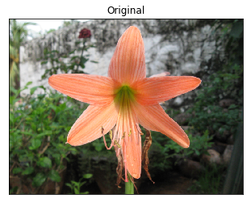

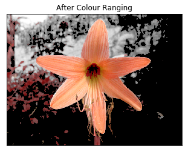

```python
from matplotlib.colors import rgb_to_hsv, hsv_to_rgb

def color_ranging_hsv(img, h_c, h_bw, s_c, v_c):
    h1, h2 = get_range_values_h(h_c, h_bw)
    vectorize_ranging = np.vectorize(ranging_h)
    vectorize_ranging_sv = np.vectorize(ranging_sv)

    shape = img.shape
    new_img = np.zeros(shape[0]*shape[1]*shape[2]
                       ).reshape(shape[0], shape[1], shape[2])
    new_img[:, :, 0] = vectorize_ranging(img[:, :, 0], h1, h2)
    new_img[:, :, 1] = vectorize_ranging_sv(img[:, :, 1], s_c)
    new_img[:, :, 2] = vectorize_ranging_sv(img[:, :, 2], v_c)
    return new_img.astype(np.uint8)


def get_range_values_h(l_c, l_bw):
    l1 = ( l_c - l_bw ) % 180
    l2 = ( l_c + l_bw ) % 180
    return l1, l2


def ranging_h(val, l1, l2):
    if l1 < l2 :
        if val <= l2 and val >= l1:
            return val
        else:
            return 0
    else:
        if   l1 <= val or l2  >= val:
            return val
        else:
            return 0

def ranging_sv(val, threshold):

    threshold = max(0,threshold)
    threshold = min(255,threshold)

    if val > threshold:
        return val
    else:
        return 0

image = cv2.imread('images/orange-flower.ppm')
image_rgb = cv2.cvtColor(image, cv2.COLOR_BGR2RGB)
image_hsv =  cv2.cvtColor(image_rgb, cv2.COLOR_RGB2HSV)
new_image_hsv = color_ranging_hsv(image_hsv, 00, 20, 50, 100)
new_image_rgb = cv2.cvtColor(new_image_hsv, cv2.COLOR_HSV2RGB)
plot_images(image_rgb,new_image_rgb)
```

## Question 4 :

Implement vector median filter and any one of the basic vector edge detectors. Show example images to demonstrate that these are better than the grayscale versions for colour images.

## Vector Median Filter

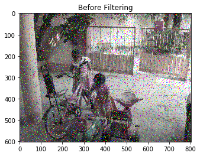

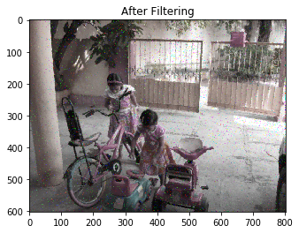

```python
def add_padding(image):
    return cv2.copyMakeBorder( image, 1, 1, 1, 1, cv2.BORDER_CONSTANT)

def euclidean_distance(vector, mean):
    return np.linalg.norm(vector-mean)

def vector_median_filter(image):
    new_image = image.copy()
    height, width = image.shape[0], image.shape[1]
    window = [[0,0,0]] * 9
    for x in range(1, height-1):  # ignore the edge pixels for simplicity (1 to width-1)
        for y in range(1, width-1): # ignore edge pixels for simplicity (1 to height-1)
            # top left pixel
            window[0] = image[x-1, y-1, :]
            window[1] = image[x-1, y, :]
            window[2] = image[x-1, y+1, :]
            window[3] = image[x, y-1, :]
            window[4] = image[x, y, :]
            window[5] = image[x, y+1, :]
            window[6] = image[x+1, y-1, :]
            window[7] = image[x+1, y, :]
            window[8] = image[x+1, y+1, :]
            mean = np.mean(window,axis=0)
            dist = []
            for i in range(9):
                dist.append(euclidean_distance(window[i], mean))
            min_dist_index = np.argmin(dist)
            new_image[x,y,:] = window[min_dist_index]
    plt.imshow(new_image)
    plt.title("After Filtering")
    plt.show()


image = cv2.imread('images/children-faded.ppm')
image_rgb = cv2.cvtColor(image, cv2.COLOR_BGR2RGB)
image_pad_rgb = add_padding(image_rgb)
plt.imshow(add_padding(image_rgb))
plt.title("Before Filtering")
plt.show()

vector_median_filter(image_pad_rgb)
```

## Median Filter (Gray Scale)

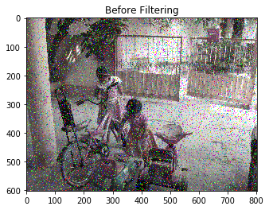

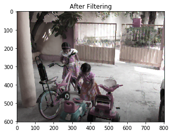

```python
def add_padding(image):
    return cv2.copyMakeBorder( image, 1, 1, 1, 1, cv2.BORDER_CONSTANT)

def euclidean_distance(vector, mean):
    return np.linalg.norm(vector-mean)

def median_filter(image):
    height, width = image.shape[0], image.shape[1]
    window = [0] * 9
    for _ in range(3):
        for x in range(1, height-1):  # ignore the edge pixels for simplicity (1 to width-1)
            for y in range(1, width-1): # ignore edge pixels for simplicity (1 to height-1)
                # top left pixel
                window[0] = image[x-1, y-1,_]
                window[1] = image[x-1, y, _]
                window[2] = image[x-1, y+1, _]
                window[3] = image[x, y-1, _]
                window[4] = image[x, y, _]
                window[5] = image[x, y+1, _]
                window[6] = image[x+1, y-1, _]
                window[7] = image[x+1, y, _]
                window[8] = image[x+1, y+1, _]
                image[x,y,_] = np.median(window)
    plt.imshow(image)
    plt.title("After Filtering")
    plt.show()

image = cv2.imread('images/children-faded.ppm')
image_rgb = cv2.cvtColor(image, cv2.COLOR_BGR2RGB)
image_pad_rgb = add_padding(image_rgb)
plt.imshow(add_padding(image_rgb))
plt.title("Before Filtering")
plt.show()

median_filter(image_pad_rgb)
```

## Sobel Vector Edge Detection

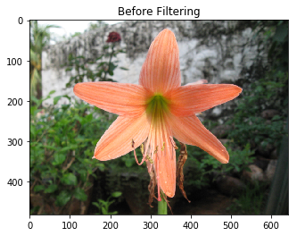

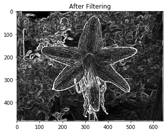

```python
def add_padding(image):
    return cv2.copyMakeBorder( image, 1, 1, 1, 1, cv2.BORDER_CONSTANT)

def sobel_edge_detector(image):
    sobel_x = [[-1,-2,-1],[0,0,0],[1,2,1]]
    sobel_y = [[-1,0,1],[-2,0,2],[-1,0,1]]
    height, width = image.shape[0], image.shape[1]
    new_image = image.copy()
    new_image = np.zeros(image.shape)

    window = [[0]] * 3
    for _ in range(3):
        for x in range(1, height-1):  # ignore the edge pixels for simplicity (1 to width-1)
            for y in range(1, width-1): # ignore edge pixels for simplicity (1 to height-1)
                # top left pixel
                window[0] = [image[x-1, y-1,_],image[x-1, y,_],image[x-1, y+1,_]]
                window[1] = [image[x, y-1,_],image[x, y,_],image[x, y+1,_]]
                window[2] = [image[x+1, y-1,_],image[x+1, y,_],image[x+1, y+1,_]]
                conv_val_x , conv_val_y = 0, 0
                conv_val_x = np.array(window)*np.array(sobel_x)
                conv_val_y = np.array(window)*np.array(sobel_y)
                new_image[x,y,_] = min(255,np.sqrt(conv_val_x.sum()**2+conv_val_y.sum()**2))
    plt.imshow(new_image.max(axis=2),cmap="gray")
    plt.title("After Filtering")
    plt.show()


image = cv2.imread('images/orange-flower.ppm')
image_rgb = cv2.cvtColor(image, cv2.COLOR_BGR2RGB)
image_pad_rgb = add_padding(image_rgb)
plt.imshow(add_padding(image_rgb))
plt.title("Before Filtering")
plt.show()


sobel_edge_detector(image_pad_rgb)
```

## Sobel Vector Edge Detection (Gray Scale)

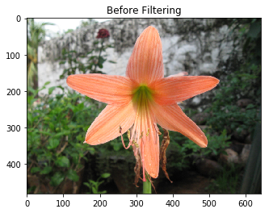

```python
def add_padding(image):
    return cv2.copyMakeBorder( image, 1, 1, 1, 1, cv2.BORDER_CONSTANT)

def sobel_edge_detector(image):
    sobel_x = [[-1,-2,-1],[0,0,0],[1,2,1]]
    sobel_y = [[-1,0,1],[-2,0,2],[-1,0,1]]
    height, width = image.shape[0], image.shape[1]
    new_image = image.copy()
    window = [[0,0,0]] * 3
    for x in range(1, height-1):  # ignore the edge pixels for simplicity (1 to width-1)
        for y in range(1, width-1): # ignore edge pixels for simplicity (1 to height-1)
            # top left pixel
            window[0] = [image[x-1, y-1],image[x-1, y],image[x-1, y+1]]
            window[1] = [image[x, y-1],image[x, y],image[x, y+1]]
            window[2] = [image[x+1, y-1],image[x+1, y],image[x+1, y+1]]
            conv_val_x , conv_val_y = 0, 0
            conv_val_x = np.array(window)*np.array(sobel_x)
            conv_val_y = np.array(window)*np.array(sobel_y)
            new_image[x,y] = min(255,np.sqrt(conv_val_x.sum()**2+conv_val_y.sum()**2))
    plt.imshow(new_image,cmap="gray")
    plt.title("After Filtering")
    plt.show()


image = cv2.imread('images/orange-flower.ppm')
image_rgb = cv2.cvtColor(image, cv2.COLOR_BGR2RGB)
plt.imshow(add_padding(image_rgb))
plt.title("Before Filtering")
plt.show()

image_gray = cv2.cvtColor(image, cv2.COLOR_BGR2GRAY)
image_pad_gray = add_padding(image_gray)
sobel_edge_detector(image_pad_gray)
```

[output not shown]